# BCB420H Assignment 2

Terrence Amponsah

# 1. Intro:

## Setup:

### R:

Installing the R packages used in this notebook.

```r
if (!requireNamespace(c("BiocManager", "GEOmetadb", "knitr", "edgeR", "limma"), quietly = TRUE)){
  install.packages("BiocManager")
  install.packages("GEOmetadb")
  install.packages("knitr")
  install.packages("edgeR")
  install.packages("limma")
}



library(DBI)
library(GEOmetadb)
library(GEOquery)
library(knitr)
library(edgeR)
library("biomaRt")
library(limma)

# A2 it seems.
library (ComplexHeatmap)
library(circlize)
```

### [Dataset](https://www.ncbi.nlm.nih.gov/geo/query/acc.cgi?acc=GSE126848) setup:

```r
suppFiles = GEOquery::getGEOSuppFiles('GSE126848')
fileNames = rownames(suppFiles)

nafld_exp = read.delim(fileNames[1], header=TRUE, check.names=FALSE)
gse <- GEOquery::getGEO("GSE126848", GSEMatrix = FALSE)
current_gpl <-names(GEOquery::GPLList(gse))[1]
current_gpl_info <-GEOquery::Meta(GEOquery::getGEO(current_gpl))
```

### Info about my dataset:

- **Platform:** Illumina NextSeq 500 (Homo sapiens)
- **Submission date:** Apr 15 2014
- **Last update date:** Mar 26 2019
- **Organism(s):** Homo sapiens
- **# Geo datasets which use this technology:** 7772
- **# Geo samples that use this technology:** 255117

I made this samples data frame to use in my A1 data, allows a mapping between the ids and the patient numbers, ids could be collected from GEO but, not sure if it is explicitly stored.

```r
patient_no <- as.character(c(1:15, 1:16, 1:14, 1:12))
group <- rep(c("normal_weight", "NASH", "NAFL", "Obese"), times=c(15,16,14,12))
ids <- c("0869", "0873", "0875", "0877", "0879", "0881", "0883", "0885", "0887",
         "0889", "0891", "0893", "0897", "0910", "2684", "2688", "2692", "2696",
         "2698", "2704", "2705", "3992", "3994", "3996", "3997", "4000", "4004",
         "4005", "4006", "4008", "2683", "2685", "2687", "2689", "2691", "2693",
         "2697", "2701", "2703", "3993", "3995", "3998", "4002", "4007", "4010",
         "0872", "0874", "0876", "0878", "0886", "0888","0890", "0892", "0894",
         "0896", "0898", "0899")
samples <- data.frame(patient_no=patient_no, group=group, ids=ids)
```

```r
nafld_expc <- nafld_exp

ensembl = biomaRt::useMart("ensembl", dataset = "hsapiens_gene_ensembl") # takes time
gene <- biomaRt::getBM(attributes = c("ensembl_gene_id", "hgnc_symbol"),
              values = nafld_exp$key, mart=ensembl)
id <- match(nafld_exp$key, gene$ensembl_gene_id)
nafld_exp$HUGO_id <- gene$hgnc_symbol[id]
```

### Cleaning the data:

```r
cpms = edgeR::cpm(nafld_exp[,2:58])

# Using n = 12 (loosest i think).
# The publication has 4 n values (12, 14, 15, 16)
# One for each category $\in$ {"obese", "NASH", "normal-weight", "NADL"}
keep = rowSums(cpms > 1 ) >= 12
filtered_ds = nafld_exp[keep,]

summarized_gene_counts_filtered <- sort(table(filtered_ds$HUGO_id),
                                        decreasing = TRUE)
```

### Normalization(TMM):

```r
filtered_ds_mtx <- as.matrix(filtered_ds[,2:58])
rownames(filtered_ds_mtx) <- filtered_ds[,59] #proper names this time around.

dge <- edgeR::DGEList(counts = filtered_ds_mtx, group=samples$group)

norm_fact <- edgeR::calcNormFactors(dge)
normalized_counts <- edgeR::cpm(norm_fact)
knitr::kable(head(normalized_counts), output="html")
```

|  | 0869 | 0872 | 0873 | 0874 | 0875 | 0876 | 0877 | 0878 | 0879 | 0881 | 0883 | 0885 | 0886 | 0887 | 0888 | 0889 | 0890 | 0891 | 0892 | 0893 | 0894 | 0896 | 0897 | 0898 | 0899 | 0910 | 2683 | 2684 | 2685 | … |
| --- | --- | --- | --- | --- | --- | --- | --- | --- | --- | --- | --- | --- | --- | --- | --- | --- | --- | --- | --- | --- | --- | --- | --- | --- | --- | --- | --- | --- | --- | --- |
| SAMD11 | 0.7357697 | 0.9210037 | 0.5245439 | 0.4843473 | 1.393402 | 1.050650 | 0.4005349 | 0.8077837 | 0.2927219 | 0.5824328 | 0.9593644 | 0.4689176 | 0.7935484 | 0.8428938 | 1.291114 | 0.2688420 | 0.4959612 | 0.6244866 | 0.4883464 | 0.3196971 | 0.5245742 | 0.4533441 | 0.9759304 | 0.4520612 | 0.4414956 | 0.4483552 | 1.6202353 | 1.1679389 | 0.6362139 | … |
| NOC2L | 23.1767467 | 23.4568142 | 21.8694455 | 30.6019429 | 25.043580 | 27.246865 | 22.3298199 | 26.6143480 | 21.2223388 | 20.2395407 | 28.9553632 | 25.3215526 | 26.2862905 | 28.0189540 | 27.531113 | 24.3301985 | 29.2617090 | 28.0572890 | 30.0145181 | 26.8945158 | 15.7372268 | 20.4328659 | 21.7674909 | 22.0003113 | 17.4992793 | 23.4041400 | 22.0351999 | 18.3950379 | 20.3588438 | … |
| ISG15 | 10.5109962 | 20.1469569 | 9.1189939 | 28.3123011 | 15.063808 | 16.810405 | 18.0991702 | 11.8616663 | 12.6846163 | 9.2703891 | 28.5628960 | 11.9908940 | 11.5064517 | 12.0039710 | 12.987091 | 11.9298625 | 14.1658909 | 18.1993226 | 24.2670572 | 12.6679963 | 5.8752313 | 13.7622314 | 12.1779140 | 11.0001557 | 6.5020258 | 13.4506552 | 9.3973647 | 8.4675571 | 12.4697918 | … |
| AGRN | 63.8017470 | 56.4978235 | 36.3549269 | 56.9328232 | 45.568018 | 58.381137 | 32.2931252 | 60.0310853 | 36.6878133 | 57.6123136 | 43.4330449 | 31.4844702 | 35.3129035 | 68.4197280 | 55.290070 | 49.0972651 | 63.6070200 | 42.4650861 | 67.3917965 | 34.6471696 | 33.9924099 | 43.4238877 | 32.5027252 | 33.6408870 | 37.4468523 | 37.2134793 | 15.0141803 | 16.3511448 | 8.9069942 | … |
| C1orf159 | 1.9708118 | 2.2161653 | 1.4929326 | 1.8052945 | 1.431062 | 1.610997 | 1.5520727 | 1.8706570 | 1.8051185 | 1.6502263 | 2.5292335 | 1.0048235 | 0.9919355 | 1.3660693 | 2.164515 | 0.9409469 | 1.3638932 | 1.2489731 | 1.7279948 | 1.3986747 | 1.4163504 | 0.9390699 | 1.0183621 | 1.5822142 | 1.3646227 | 1.3450655 | 0.4320627 | 0.4087786 | 1.0179422 | … |
| SDF4 | 163.4722687 | 165.9821438 | 130.2886338 | 146.1848207 | 165.024013 | 174.653108 | 141.9145170 | 156.8801024 | 172.0229120 | 162.8870466 | 204.3446267 | 141.2111983 | 178.2508077 | 160.5858102 | 170.351136 | 171.8908358 | 190.5730795 | 190.8252504 | 211.0407540 | 161.0074353 | 98.5674971 | 125.2201148 | 125.2585440 | 141.6081684 | 123.4582183 | 129.3953028 | 156.1906814 | 83.6828233 | 105.2297741 | … |

```r
conversion_stash <- "nafld_id_conversion.rds"

if(file.exists(conversion_stash)){
  nafld_id_conversion <- readRDS(conversion_stash)
} else {
  nafld_id_conversion <- getBM(
                            attributes = c("ensembl_gene_id", "hgnc_symbol"),
                            filters = c("ensembl_gene_id"),
                            values = filtered_ds$key,
                            mart = ensembl
  )
}
nc_annot <- merge(nafld_id_conversion, normalized_counts, by.x = 2, by.y = 0, all.y = TRUE)

missing_ids <- nc_annot$hgnc_symbol[which(is.na(nc_annot$hgnc_symbol) | is.na(nc_annot$ensembl_gene_id))]

mid_ds <- data.frame(gsub("\\.", "-", missing_ids))
colnames(mid_ds) <- c("missing_ids")

old_mapping <- merge(nafld_exp[,c(1,ncol(nafld_exp))],
                     mid_ds, by.x="HUGO_id", by.y = "missing_ids")
dots_to_dashes <- data.frame(c(data.frame(gsub('\\.', '-', missing_ids), missing_ids)))

dot_hgnc <- merge(old_mapping, dots_to_dashes, by.x = 0, by.y = 0)
dot_hgnc <- dot_hgnc[c("key", "missing_ids")]

mis <- nc_annot[which(is.na(nc_annot$ensembl_gene_id) | is.na(nc_annot$hgnc_symbol)),]
mis_withids <- merge(dot_hgnc, mis, by.x = "missing_ids", by.y = "hgnc_symbol")
colnames(mis_withids)[0:1] <- colnames(nc_annot)[0:1]

finalized_ncc <- rbind(nc_annot[which(
  !is.na(nc_annot$ensembl_gene_id) | !is.na(nc_annot$hgnc_symbol)),], mis_withids[, colnames(nc_annot)])

dup_ens <- finalized_ncc$ensembl_gene_id[which(duplicated(finalized_ncc$ensembl_gene_id))]
nodup_f_nc <- finalized_ncc[-which(duplicated(finalized_ncc$ensembl_gene_id)),]

final_ncc <- nodup_f_nc[-which(is.na(nodup_f_nc$ensembl_gene_id)),]
```

## HeatMap Prep:

### Normalized counts to numerical matrix:

```r
knitr::kable(final_ncc[1:5,1:5], type="html")
```

| hgnc_symbol | ensembl_gene_id | 0869 | 0872 | 0873 |
| --- | --- | --- | --- | --- |
| A1BG | ENSG00000121410 | 3.3635188 | 3.453764 | 2.340273 |
| A1CF | ENSG00000148584 | 465.5845775 | 324.078193 | 423.024477 |
| A2M | ENSG00000175899 | 895.8784852 | 497.831306 | 1343.356917 |
| A4GALT | ENSG00000128274 | 0.9722672 | 2.244947 | 1.815729 |
| AAAS | ENSG00000094914 | 13.6117401 | 15.282906 | 17.390648 |

```r
num_matrix <- final_ncc[,3:ncol(final_ncc)]
rownames(num_matrix) <- final_ncc$ensembl_gene_id
colnames(num_matrix) <- colnames(final_ncc[, 3:ncol(final_ncc)])
```

now that the data is in matrix form, I a Heatmap can be created.

### Heatmap (with row-normalization)

```r
normalized_matrix <- t(scale(t(num_matrix)))

if(min(normalized_matrix) == 0) {
  heatmap_col = circlize::colorRamp2(c(0, max(normalized_matrix)),
                          c( "white", "red"))
} else {
  heatmap_col = circlize::colorRamp2(c(min(normalized_matrix), 0, max(normalized_matrix)),
                           c("blue", "white", "red"))
}

current_hm <- ComplexHeatmap::Heatmap(as.matrix(normalized_matrix),
                    show_row_dend = TRUE, show_column_dend = TRUE,
                    col = heatmap_col, show_column_names = TRUE,
                    show_row_names = FALSE, show_heatmap_legend = TRUE)
```

```
## `use_raster` is automatically set to TRUE for a matrix with more than
## 2000 rows. You can control `use_raster` argument by explicitly setting
## TRUE/FALSE to it.
##
## Set `ht_opt$message = FALSE` to turn off this message.
```

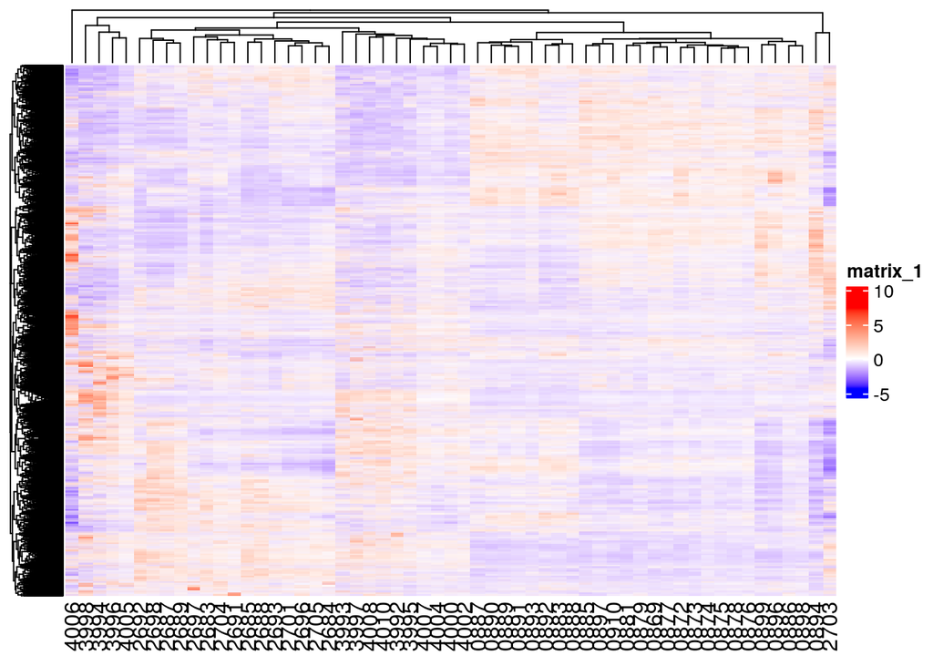

```r
current_hm
```

```r
nw_samples <- samples$ids[which(samples$group == "normal_weight")]
nash_samples <- samples$ids[which(samples$group == "NASH")]
ob_samples <- samples$ids[which(samples$group == "Obese")]
nafl_samples <- samples$ids[which(samples$group == "NAFL")]

goi_list <- c("HMGCS2",  "LDLR",  "SCD1", "RS2",  "G6PASE", "PPARA", "TGFB", "A-SMA",  "COL1A1",  "COL1A2","COL3A1",  "COL6A1",  "COL6A2",  "PDGF", "AEBP1", "DPT", "EFEMP1", "FBLN5","ITGBL1",  "LOXL4",  "THBS2",  "VCAN", "MAT1A", "ANTRX1", "CLDN11", "EPCAM", "MGP", "PODN","STMN2")
goi <- which(final_ncc$hgnc_symbol == goi_list[1])

(goi_nw_samples <- t(final_ncc[goi,nw_samples]))
```

```
##          4644
## 0869 1570.080
## 0873 2171.652
## 0875 1544.078
## 0877 2029.535
## 0879 2099.450
## 0881 2102.243
## 0883 1435.514
## 0885 2142.284
## 0887 2808.348
## 0889 2213.309
## 0891 1962.137
## 0893 1749.462
## 0897 2569.794
## 0910 2026.834
## 2684 1200.992
```

```r
colnames(goi_nw_samples) <- "normal_weight_samples"
goi_nash_samples <- t(final_ncc[goi,nash_samples])
colnames(goi_nash_samples) <- "NASH_samples"
goi_ob_samples <- final_ncc[goi,ob_samples]
colnames(goi_ob_samples) <- "Obese_samples"
goi_nafl_sample <- final_ncc[goi,nafl_samples]
colnames(goi_nafl_sample) <- "NAFL_samples"
```

### T.test between normal weight and NAFL.

```r
t.test(x=t(goi_nw_samples), y=t(goi_nafl_sample))
```

```
##
##  Welch Two Sample t-test
##
## data:  t(goi_nw_samples) and t(goi_nafl_sample)
## t = 5.0134, df = 26.49, p-value = 3.088e-05
## alternative hypothesis: true difference in means is not equal to 0
## 95 percent confidence interval:
##   421.1659 1005.6450
## sample estimates:
## mean of x mean of y
##  1975.048  1261.642
```

### MDS Plot for samples.

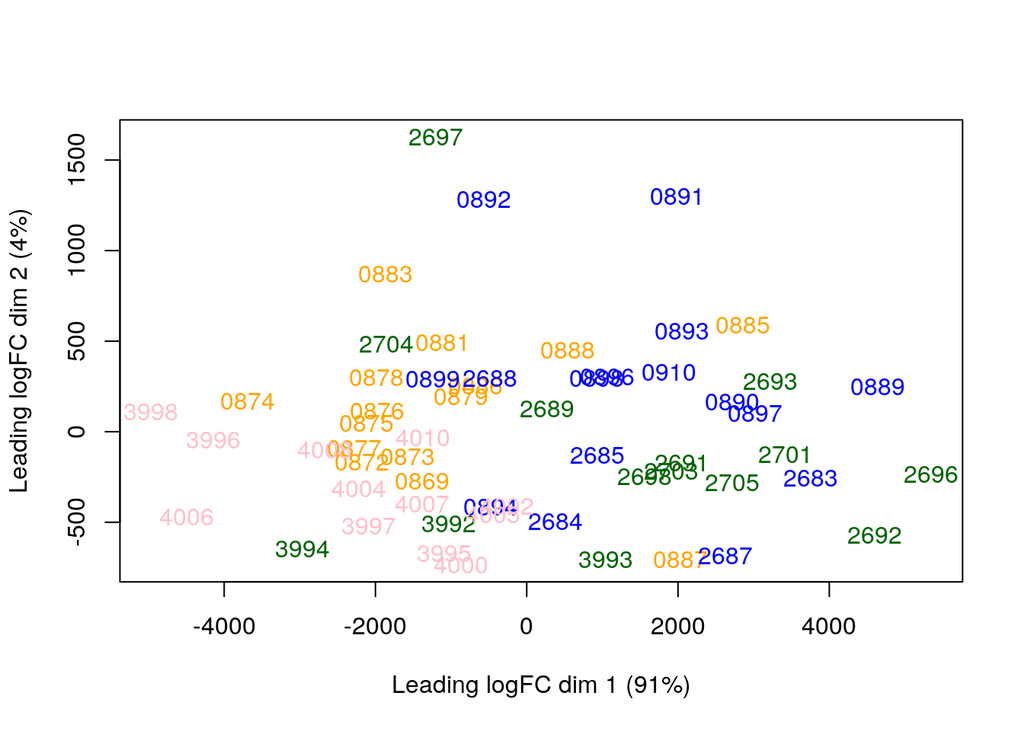

```r
limma::plotMDS(num_matrix,
               col = c("darkgreen", "blue", "orange", "pink")[factor(samples$group)])
```

## Model Creation

Model design based on the “healthy,” “obese,” “NASH,” “NAFL” groups.

```r
model_design <- model.matrix( ~ samples$group)
knitr::kable(model_design[1:5,], type="html")
```

[output not shown]

```r
expressionMatrix <- as.matrix(final_ncc[,3:ncol(final_ncc)])
rownames(expressionMatrix) <- final_ncc$ensembl_gene_id
colnames(expressionMatrix) <- colnames(final_ncc)[3:ncol(final_ncc)]

minimalSet <- Biobase::ExpressionSet(assayData=expressionMatrix)

fit <- limma::lmFit(minimalSet, model_design)

fit2 <- limma::eBayes(fit, trend=TRUE)

topfit <- limma::topTable(fit2,
                  coef = ncol(model_design),
                  adjust.method= "BH",
                  number = nrow(expressionMatrix))

output_hits <- merge(final_ncc[,1:2],
                     topfit,
                     by.x = "ensembl_gene_id", by.y = "row.names", all.y = TRUE)
# REMEMBER TO USE NAMES COLUMNS, NUMERICAL ONES DON'T WORK FOR SOME REASON!

output_hits <- output_hits[order(output_hits$P.Value),]

knitr::kable(output_hits[1:10,], type="html",row.names=FALSE)
```

| ensembl_gene_id | hgnc_symbol | logFC | AveExpr | t | P.Value | adj.P.Val | B |
| --- | --- | --- | --- | --- | --- | --- | --- |
| ENSG00000066027 | PPP2R5A | -22.327525 | 44.193345 | -7.679437 | 0 | 3.80e-06 | 10.371045 |
| ENSG00000261150 | EPPK1 | 3.003006 | 1.632018 | 7.410299 | 0 | 4.00e-06 | 9.645415 |
| ENSG00000091317 | CMTM6 | -47.556252 | 127.323330 | -7.373772 | 0 | 4.00e-06 | 9.546333 |
| ENSG00000160714 | UBE2Q1 | -10.240192 | 35.455851 | -7.148350 | 0 | 6.40e-06 | 8.931968 |
| ENSG00000187531 | SIRT7 | 4.344310 | 5.896044 | 7.113851 | 0 | 6.40e-06 | 8.837533 |
| ENSG00000262814 | MRPL12 | 22.649562 | 14.040580 | 6.960821 | 0 | 9.40e-06 | 8.417441 |
| ENSG00000054965 | FAM168A | -19.940565 | 49.202835 | -6.730461 | 0 | 1.92e-05 | 7.781805 |
| ENSG00000131409 | LRRC4B | 1.601598 | 1.243290 | 6.686534 | 0 | 1.98e-05 | 7.660215 |
| ENSG00000196636 | SDHAF3 | 3.626472 | 7.528500 | 6.645697 | 0 | 2.05e-05 | 7.547078 |
| ENSG00000147100 | SLC16A2 | -85.904995 | 185.858863 | -6.556067 | 0 | 2.48e-05 | 7.298467 |

### Genes with p-values below threshold (0.05)

```r
length(which(output_hits$P.Value < 0.05)) # No. of genes with p-value < 0.05
```

```
## [1] 4246
```

```r
length(which(output_hits$adj.P.Val < 0.05)) # No. of genes which _
```

```
## [1] 2550
```

## Model #2, (group (from model 1) + patient_no)

```r
mdp_pat <- model.matrix( ~samples$patient_no + samples$group)
fit_pat <- limma::lmFit(minimalSet, mdp_pat)
fit2_pat <- limma::eBayes(fit_pat, trend=TRUE)
topfit_pat <- limma::topTable(fit2_pat,
                       coef=ncol(mdp_pat),
                       adjust.method = "BH",
                       number = nrow(expressionMatrix))
output_hit_pat <- merge(final_ncc[,1:2],
                     topfit_pat,
                     by.x = "ensembl_gene_id", by.y = "row.names", all.y = TRUE)

output_hit_pat <- output_hit_pat[order(output_hit_pat$P.Value),]
knitr::kable(output_hit_pat[1:10, 2:8], type="html", row.names = FALSE)
```

| hgnc_symbol | logFC | AveExpr | t | P.Value | adj.P.Val | B |
| --- | --- | --- | --- | --- | --- | --- |
| EPPK1 | 3.045845 | 1.632018 | 7.652688 | 0e+00 | 3.13e-05 | 8.573152 |
| SDHAF3 | 3.631651 | 7.528500 | 7.261753 | 0e+00 | 5.38e-05 | 7.723579 |
| MRPL12 | 23.888710 | 14.040580 | 7.104866 | 0e+00 | 5.90e-05 | 7.376061 |
| CMTM6 | -48.450414 | 127.323330 | -6.849565 | 0e+00 | 6.43e-05 | 6.803001 |
| GNB1 | -30.605344 | 131.544209 | -6.805154 | 0e+00 | 6.43e-05 | 6.702401 |
| PPP2R5A | -22.322361 | 44.193345 | -6.793030 | 0e+00 | 6.43e-05 | 6.674894 |
| UBE2Q1 | -10.497082 | 35.455851 | -6.781227 | 0e+00 | 6.43e-05 | 6.648095 |
| LRRC4B | 1.561056 | 1.243290 | 6.742067 | 0e+00 | 6.43e-05 | 6.559052 |
| PIN1 | 9.610887 | 16.121158 | 6.727816 | 0e+00 | 6.43e-05 | 6.526597 |
| BORCS6 | 3.593534 | 5.119038 | 6.701080 | 1e-07 | 6.43e-05 | 6.465643 |

### Up-regulated Genes:

```r
length(which(output_hit_pat$P.Value < 0.05 & output_hit_pat$logFC > 0))
```

```
## [1] 2312
```

### Down-regulated Genes:

```r
length(which(output_hit_pat$P.Value < 0.05 & output_hit_pat$logFC < 0))
```

```
## [1] 2078
```

### P-values for model #2 :

```r
length(which(output_hit_pat$P.Value < 0.05))
```

```
## [1] 4390
```

```r
length(which(output_hit_pat$adj.P.Val < 0.05))
```

```
## [1] 2640
```

## P-value plots:

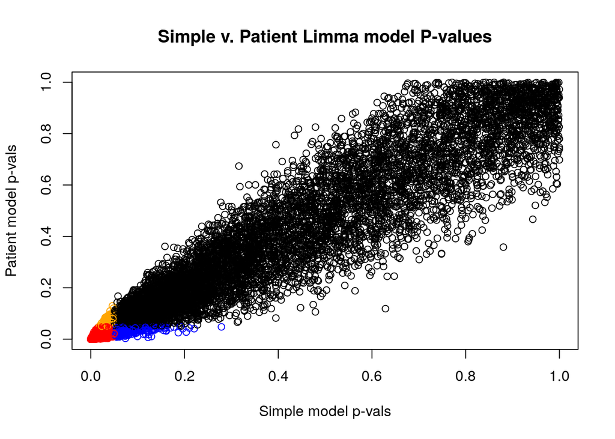

```r
simple_model_pvals <- data.frame(ensembl_id =
                                   output_hits$ensembl_gene_id,
                                 simple_pvals = output_hits$P.Value)

pm_pvals <- data.frame(ensembl_id =
                                   output_hit_pat$ensembl_gene_id,
                                 pat_pvals = output_hit_pat$P.Value)

two_models_pvals <- merge(simple_model_pvals, pm_pvals, by.x=1, by.y=1)
two_models_pvals$color <- "black"
two_models_pvals$color[two_models_pvals$simple_pvals<0.05] <- "orange"
two_models_pvals$color[two_models_pvals$pat_pvals<0.05] <- "blue"
two_models_pvals$color[two_models_pvals$simple<0.05 & two_models_pvals$pat_pvals<0.05] <- "red"

plot(two_models_pvals$simple_pvals, two_models_pvals$pat_pvals, col = two_models_pvals$color,
     xlab = "Simple model p-vals", ylab = "Patient model p-vals", main="Simple v. Patient Limma model P-values")
```

### GOI highlighted

```r
goi_ens <- final_ncc$ensembl_gene_id[which(final_ncc$hgnc_symbol %in% goi_list)]

tm_pvals <- merge(simple_model_pvals, pm_pvals, by.x=1, by.y=1)
tm_pvals$color <- "darkgrey"
tm_pvals$color[tm_pvals$ensembl_id %in% goi_ens] <- "orange"

plot(tm_pvals$simple_pvals, tm_pvals$pat_pvals,
     col = tm_pvals$color, xlab = "Simple model p-vals", ylab = "Patient model p-vals", main="Simple v. Patient Limma model P-values") + abline(h = 0.5, v = 0.5, lty=2)
```

```
## integer(0)
```

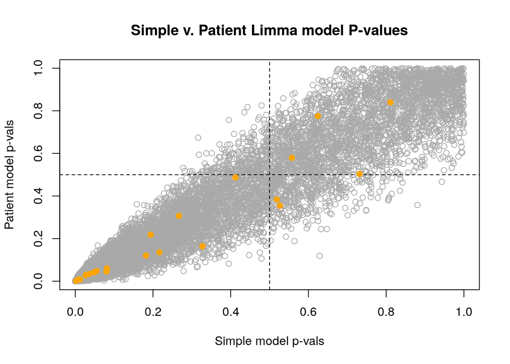

```r
points(tm_pvals[which(tm_pvals$ensembl_id %in% goi_ens), 2:3], pch=20, col="orange", cex=1.5)
```

```r
which(final_ncc$hgnc_symbol %in% goi_list)
```

```
##  [1]   278  2078  2228  2229  2235  2243  2244  2994  3148  3343  3664  4618
## [13]  5057  5455  5567  5870  6065  7802  7892 10615 11624
```

## Heatmap of the Top Hits.

```r
tophits_ms <- output_hit_pat$ensembl_gene_id[output_hit_pat$P.Value<0.01]
ms_mtx <- t(scale(t(num_matrix[which(rownames(num_matrix)%in% tophits_ms),])))

ms_mtx <- ms_mtx[, c(which(colnames(ms_mtx) %in% samples$ids[which(samples$group == "normal_weight")]),
                     which(colnames(ms_mtx) %in% samples$ids[which(samples$group == "Obese")]),
                     which(colnames(ms_mtx) %in% samples$ids[which(samples$group == "NASH")]),
                     which(colnames(ms_mtx) %in% samples$ids[which(samples$group == "NAFL")]))]

if(min(ms_mtx) == 0) {
  heatmap_colo = circlize::colorRamp2(c(0, max(ms_mtx)),
                          c( "white", "red"))
} else {
  heatmap_colo = circlize::colorRamp2(c(min(ms_mtx), 0, max(ms_mtx)),
                           c("blue", "white", "red"))
}

tophits_heatmap_cl <- ComplexHeatmap::Heatmap(as.matrix(ms_mtx),
                           cluster_rows = TRUE, cluster_columns = FALSE,
                           show_row_dend = TRUE, show_column_dend = TRUE,
                           col = heatmap_colo, show_column_names = TRUE,
                           show_row_names = FALSE, show_heatmap_legend = TRUE)
```

```
## `use_raster` is automatically set to TRUE for a matrix with more than
## 2000 rows. You can control `use_raster` argument by explicitly setting
## TRUE/FALSE to it.
##
## Set `ht_opt$message = FALSE` to turn off this message.
```

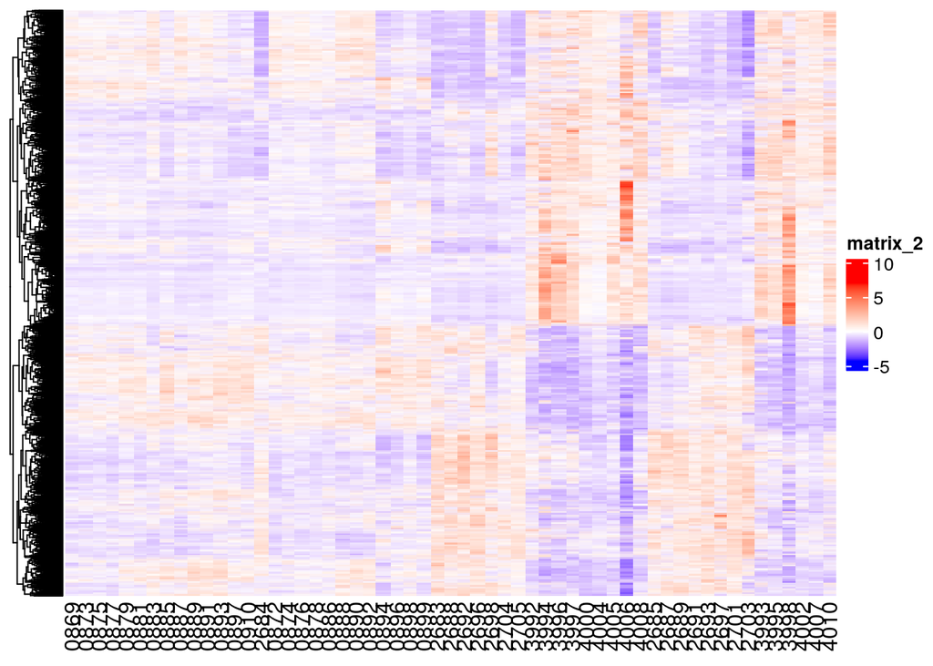

```r
tophits_heatmap_cl
```

## Thresholded List of genes:

```r
ohp_named <- merge(nafld_exp[,c(1,ncol(nafld_exp))], output_hit_pat, by.x="key", by.y="ensembl_gene_id")
ohp_named[,"rank"] <- -log(ohp_named$P.Value, base=10) * sign(ohp_named$logFC)
ohp_named <- ohp_named[order(ohp_named$rank), ]

urg <- ohp_named$hgnc_symbol[which(ohp_named$P.Value < 0.05 & ohp_named$logFC > 0)]
drg <- ohp_named$hgnc_symbol[which(ohp_named$P.Value < 0.05 & ohp_named$logFC < 0)]

write.table(x=c(urg, drg),
            file=file.path('./data', 'nafld_reg_g.txt'), sep = "\t",
            row.names = FALSE, col.names = FALSE, quote=FALSE)

write.table(x=urg,
            file=file.path('./data', 'nafld_urg.txt'), sep="\t",
            row.names = FALSE, col.names = FALSE, quote = FALSE)

write.table(x = drg, file=file.path('./data', 'nafld_drg.txt') ,  sep="\t",
            row.names=FALSE, col.names = FALSE, quote = FALSE)

write.table(x = data.frame(genename=ohp_named$hgnc_symbol, F_stat=ohp_named$rank),
            file=file.path('./data', 'rankedGL.txt'), sep="\t",
            row.names = FALSE, col.names = FALSE, quote=FALSE)
```

# Answers:

## Differential Gene Expression:

1. & 2. Here are the number of genes which were significantly differentially expressed & the number of genes which pass correction. The standard threshold p-value of 0.05 was used to categorize a genes a “significantly” differentially expressed.

```r
length(which(output_hits$P.Value < 0.05)) # No. of genes with p-value < 0.05
## [1] 4246
length(which(output_hits$adj.P.Val < 0.05)) # No. of genes which _
## [1] 2550
```

```r
length(which(output_hit_pat$P.Value < 0.05)) # No. of genes with p-value < 0.05
```

```
## [1] 4390
```

```r
length(which(output_hit_pat$adj.P.Val < 0.05)) # No. of genes which pass correction
```

```
## [1] 2640
```

3. MA Plot of Example NAFL vs Normal-weight:

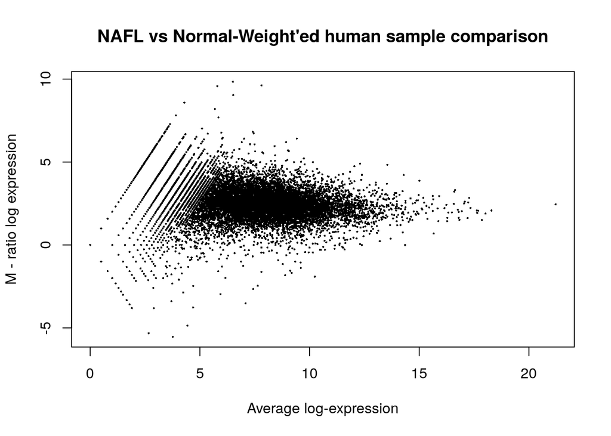

```r
limma::plotMA(log2(nafld_expc[,c(2,ncol(nafld_expc))]), ylab="M - ratio log expression", main="NAFL vs Normal-Weight'ed human sample comparison")
```

## Thresholded ORA

1. [G:Profiler](https://biit.cs.ut.ee/gprofiler/gost)(Raudvere et al. 2019) was used for the thresholded ORA. G:Profiler was used because it has support for both gene identifiers that were used and produced results when the query was run.
2. Gene Ontology (MF, CC, BP) (release: 2021-12-15), Reactome (class: 2022-1-3) and Human Protein Atlas(script: 21-12-17) were used for annotation. These sets have information which may provide insights for my dataset.
3. After running the complete set of up- and down-regulated genes with G:Profiler, 1406 genesets are returned. User Threshold is 0.05 (with BHFDR). Results were also filtered for term sizes between 3 and 1000.
4. When re-running this analysis with the up-regulated genes, the top results are very different with the down-regulated set compared to the up-regulated set, which has some returned genesets in common (e.g. GO:MF-transcription corepressor activity)

Raudvere, Uku, Liis Kolberg, Ivan Kuzmin, Tambet Arak, Priit Adler, Hedi Peterson, and Jaak Vilo. 2019. “G:profiler: A Web Server for Functional Enrichment Analysis and Conversions of Gene Lists (2019 Update).” *Nucleic Acids Res.* 47 (W1): W191–98.

Suppli, Malte P, Kristoffer T G Rigbolt, Sanne S Veidal, Sara Heebøll, Peter Lykke Eriksen, Mia Demant, Jonatan I Bagger, et al. 2019. “Hepatic Transcriptome Signatures in Patients with Varying Degrees of Nonalcoholic Fatty Liver Disease Compared with Healthy Normal-Weight Individuals.” *Am. J. Physiol. Gastrointest. Liver Physiol.* 316 (4): G462–72.